# Module 04: SEM, Regression, and Causal Inference

## 3.3 Specifying the SEM

```r
poldem_model <- '
  # ==============================
  # MEASUREMENT MODEL
  # ==============================
  # Each latent variable defined by its indicators
  # lavaan estimates one loading per item
  # With std.lv=TRUE: all factor variances fixed to 1

  ind60 =~ x1 + x2 + x3        # Industrialisation 1960
  dem60 =~ y1 + y2 + y3 + y4   # Democracy 1960
  dem65 =~ y5 + y6 + y7 + y8   # Democracy 1965

  # ==============================
  # STRUCTURAL MODEL
  # ==============================
  # These are theoretically hypothesised causal paths
  # Direction is determined by theory, not data

  dem60 ~ ind60          # H1: Industrialisation → early democracy
  dem65 ~ ind60 + dem60  # H2: Ind. → later democracy (possibly mediated by dem60)
                         # H3: Early democracy → later democracy (stability)

  # ==============================
  # CORRELATED RESIDUALS
  # ==============================
  # Same concept measured at two time points shares method variance
  # beyond what the latent factors capture. Theoretically justified.

  y1 ~~ y5   # Press freedom: same item at t1 and t2 share measurement bias
  y2 ~~ y4   # Within-wave item similarity
  y2 ~~ y6
  y3 ~~ y7
  y4 ~~ y8
  y6 ~~ y8
'
cat("Model specified. 3 latent variables, 3 structural paths, 6 correlated residuals.\n")
```

```
## Model specified. 3 latent variables, 3 structural paths, 6 correlated residuals.
```

## 3.4 Fitting and Reading SEM Output

```r
sem_fit <- sem(
  model     = poldem_model,
  data      = PoliticalDemocracy,
  estimator = "ML",    # standard ML for this dataset (continuous indicators, N=75)
  std.lv    = TRUE     # fix latent variances to 1 for standardised loadings
)

summary(sem_fit, fit.measures=TRUE, standardized=TRUE, ci=TRUE)
```

```
## lavaan 0.6-21 ended normally after 73 iterations
##
##   Estimator                                         ML
##   Optimization method                           NLMINB
##   Number of model parameters                        31
##
##   Number of observations                            75
##
## Model Test User Model:
##
##   Test statistic                                38.125
##   Degrees of freedom                                35
##   P-value (Chi-square)                           0.329
##
## Model Test Baseline Model:
##
##   Test statistic                               730.654
##   Degrees of freedom                                55
##   P-value                                        0.000
##
## User Model versus Baseline Model:
##
##   Comparative Fit Index (CFI)                    0.995
##   Tucker-Lewis Index (TLI)                       0.993
##
## Loglikelihood and Information Criteria:
##
##   Loglikelihood user model (H0)              -1547.791
##   Loglikelihood unrestricted model (H1)      -1528.728
##
##   Akaike (AIC)                                3157.582
##   Bayesian (BIC)                              3229.424
##   Sample-size adjusted Bayesian (SABIC)       3131.720
##
## Root Mean Square Error of Approximation:
##
##   RMSEA                                          0.035
##   90 Percent confidence interval - lower         0.000
##   90 Percent confidence interval - upper         0.092
##   P-value H_0: RMSEA <= 0.050                    0.611
```

[output cut: 100 more lines]

```
##    Std.lv  Std.all
##     0.082    0.154
##     0.120    0.053
##     0.467    0.239
##     1.891    0.277
##     7.373    0.486
##     5.067    0.478
##     3.148    0.285
##     2.351    0.347
##     4.954    0.443
##     3.431    0.322
##     3.254    0.315
##     1.000    1.000
##     0.800    0.800
##     0.039    0.039
```

**Reading the SEM output — what is different from CFA:**

In a SEM, the “Regressions” section (labelled `~`) is new compared to CFA. This is where the structural paths live:

New Sections in SEM Output vs. CFA Output

[output not shown]

## 3.5 Extracting and Interpreting Structural Paths

```r
# Extract structural paths cleanly
struct <- parameterEstimates(sem_fit, standardized=TRUE) |>
  filter(op == "~") |>
  select(Outcome=lhs, Predictor=rhs, b=est, SE=se, z=z, p=pvalue,
         beta=std.all, CI_low=ci.lower, CI_high=ci.upper) |>
  mutate(across(c(b,SE,z,beta,CI_low,CI_high), ~round(.x,3)),
         p = round(p, 4),
         Sig = case_when(p<.001~"***",p<.01~"**",p<.05~"*",TRUE~""))

kbl(struct,
    caption="SEM Structural Path Estimates — Political Democracy Model") |>
  kable_styling(bootstrap_options=c("striped","hover")) |>
  footnote(general=paste(
    "b = unstandardised coefficient | beta = standardised | SE = standard error",
    "\n*** p<.001, ** p<.01, * p<.05",
    "\nInterpret beta like a standardised regression coefficient:",
    "A 1 SD change in predictor → beta SD change in outcome."
  ))
```

SEM Structural Path Estimates — Political Democracy Model

| Outcome | Predictor | b | SE | z | p | beta | CI_low | CI_high | Sig |
| --- | --- | --- | --- | --- | --- | --- | --- | --- | --- |
| dem60 | ind60 | 0.499 | 0.144 | 3.460 | 0.0005 | 0.447 | 0.216 | 0.782 | *** |
| dem65 | ind60 | 0.923 | 0.628 | 1.469 | 0.1418 | 0.182 | -0.308 | 2.154 |  |
| dem65 | dem60 | 4.010 | 2.617 | 1.533 | 0.1254 | 0.885 | -1.118 | 9.139 |  |

Note:  
b = unstandardised coefficient | beta = standardised | SE = standard error *** p<.001, ** p<.01, * p<.05 Interpret beta like a standardised regression coefficient: A 1 SD change in predictor → beta SD change in outcome.

**Extracting R² values:**

```r
lavInspect(sem_fit, "rsquare") |>
  round(3) |>
  print()
```

```
##    x1    x2    x3    y1    y2    y3    y4    y5    y6    y7    y8 dem60 dem65
## 0.846 0.947 0.761 0.723 0.514 0.522 0.715 0.653 0.557 0.678 0.685 0.200 0.961
```

```r
cat("\nInterpretation:\n")
```

```
##
## Interpretation:
```

```r
cat("The model explains a high proportion of variance in dem65 (via the very stable path from dem60).\n")
```

```
## The model explains a high proportion of variance in dem65 (via the very stable path from dem60).
```

```r
cat("A lower R² for dem60 means industrialisation alone explains less of early democracy —\n")
```

```
## A lower R² for dem60 means industrialisation alone explains less of early democracy —
```

```r
cat("other factors (not in the model) also determine 1960 democracy.\n")
```

```
## other factors (not in the model) also determine 1960 democracy.
```

## 3.6 Fit Evaluation

```r
fit_table(sem_fit) |>
  kbl(caption="SEM Fit Indices — Political Democracy") |>
  kable_styling(bootstrap_options=c("striped","hover")) |>
  row_spec(c(4,5), background="#EBF5FB") |>
  row_spec(6, background="#EAFAF1") |>
  row_spec(10, background="#FEF9E7")
```

SEM Fit Indices — Political Democracy

| Index | Value | Threshold |
| --- | --- | --- |
| χ² | 38.125 |  |
| df | 35.000 |  |
| p(χ²) | 0.329 | > .05 |
| CFI | 0.995 | ≥ .95 |
| TLI | 0.993 | ≥ .95 |
| RMSEA | 0.035 | ≤ .06 |
| RMSEA CI low | 0.000 |  |
| RMSEA CI high | 0.092 |  |
| SRMR | 0.044 | ≤ .08 |
| AIC | 3157.582 | lower=better |
| BIC | 3229.424 | lower=better |

## 3.7 Path Diagram

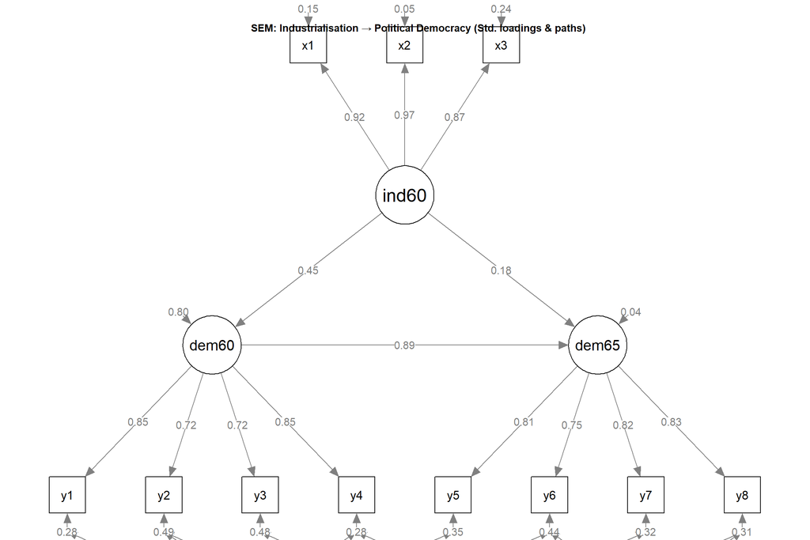

```r
semPaths(sem_fit, whatLabels="std", layout="tree2",
         style="lisrel", edge.label.cex=0.65,
         residuals=TRUE, intercepts=FALSE, nCharNodes=0, mar=c(2,2,2,2))
title("SEM: Industrialisation → Political Democracy (Std. loadings & paths)",
      cex.main=0.9)
```

# 4 Part C: Mediation Analysis

## 4.1 What Mediation Means

A mediation model asks: does X affect Y *through* a mediating variable M?

- **Direct effect (c’):** X → Y not via M
- **Indirect effect (a×b):** X → M → Y
- **Total effect (c):** c = c’ + (a×b)

In the Political Democracy example: industrialisation (X) affects 1965 democracy (Y) partly directly and partly through 1960 democracy (M). We want to estimate each component.

## 4.2 Why Standard Errors for Indirect Effects Need Bootstrapping

The indirect effect is a *product* of two estimated quantities (a × b). Products of regression coefficients follow a skewed, asymmetric sampling distribution — not a normal distribution. Standard confidence intervals (estimate ± 1.96 SE) assume symmetry and are therefore biased for indirect effects, especially when: - Either a or b is small - The sample size is modest - You want to test whether the indirect effect is different from zero

**Bootstrapped confidence intervals** solve this by empirically sampling the distribution of the indirect effect: fit the model on 1,000+ resampled datasets, compute a×b in each, and take the 2.5th and 97.5th percentiles. No normality assumption needed.

```r
med_model <- '
  ind60 =~ x1 + x2 + x3
  dem60 =~ y1 + y2 + y3 + y4
  dem65 =~ y5 + y6 + y7 + y8

  # Label each path for the defined parameters below
  dem60 ~ a*ind60
  dem65 ~ b*dem60 + c*ind60
  y1~~y5; y2~~y4; y2~~y6; y3~~y7; y4~~y8; y6~~y8

  # Define decomposition of effects
  indirect := a * b          # path through dem60
  direct   := c              # direct path bypassing dem60
  total    := c + (a * b)    # = direct + indirect
  prop_med := (a*b) / (c+a*b) # proportion of total that is indirect
'

set.seed(2024)
med_fit <- sem(med_model, data=PoliticalDemocracy,
               std.lv=TRUE,
               se="bootstrap", bootstrap=1000)

# Extract defined parameters with bootstrapped CIs
med_results <- parameterEstimates(med_fit, boot.ci.type="bca.simple",
                                   level=0.95) |>
  filter(label %in% c("indirect","direct","total","prop_med")) |>
  select(label, est, se, ci.lower, ci.upper, pvalue) |>
  mutate(
    across(c(est,se,ci.lower,ci.upper), ~round(.x,3)),
    pvalue   = round(pvalue, 4),
    CI_includes_0 = ifelse(ci.lower < 0 & ci.upper > 0, "Yes — NOT significant",
                            "No — significant"),
    label = dplyr::recode(label,
      indirect = "Indirect: ind60 → dem60 → dem65",
      direct   = "Direct: ind60 → dem65",
      total    = "Total: ind60 → dem65",
      prop_med = "Proportion mediated"
    )
  )

kbl(med_results,
    caption="Mediation Analysis: Effect of Industrialisation on 1965 Democracy (1,000 Bootstrap Samples)",
    col.names=c("Effect","Estimate","SE","CI lower","CI upper","p","CI includes 0?")) |>
  kable_styling(bootstrap_options=c("striped","hover")) |>
  row_spec(1, bold=TRUE) |>
  footnote(general=paste(
    "Bootstrap BCa confidence intervals (bias-corrected, accelerated).",
    "\nIf the 95% CI for the indirect effect does not include 0, the indirect effect is significant.",
    "\nProportion mediated: what fraction of the total effect operates through dem60."
  ))
```

Mediation Analysis: Effect of Industrialisation on 1965 Democracy (1,000 Bootstrap Samples)

| Effect | Estimate | SE | CI lower | CI upper | p | CI includes 0? |
| --- | --- | --- | --- | --- | --- | --- |
| Indirect: ind60 → dem60 → dem65 | 2.002 | 20.585 | 0.855 | 160.707 | 0.9225 | No — significant |
| Direct: ind60 → dem65 | 0.923 | 8.613 | 0.312 | 77.613 | 0.9147 | No — significant |
| Total: ind60 → dem65 | 2.925 | 28.740 | 1.463 | 290.483 | 0.9189 | No — significant |
| Proportion mediated | 0.685 | 0.123 | 0.431 | 0.952 | 0.0000 | No — significant |

Note:  
Bootstrap BCa confidence intervals (bias-corrected, accelerated). If the 95% CI for the indirect effect does not include 0, the indirect effect is significant. Proportion mediated: what fraction of the total effect operates through dem60.

**Interpreting mediation results:**

- **Indirect effect:** If the CI excludes zero → the mediation is statistically significant → industrialisation does affect 1965 democracy *through* its effect on 1960 democracy.
- **Direct effect:** If small and non-significant → *complete mediation* — the whole effect operates through the mediator.
- **Proportion mediated:** A value near 1.0 means the mediator explains almost all of the total effect.